# MPDW Prak Pertemuan 5

G1401211094 Hanifa Rahmacindia Nasution

2023-09-26

Data sendiri yang awal cek stasioner ragam dan rataan cek data ada negatifnya apa nggak motongnya gak boleh pas mau turun atau pas mau naik (karena ngaruh ke data forecastnya, kayak bakal turun misal motong pas mau turun tapi ternyata data aktualnya ehh naik) harusnya dipotongnya pas naik atau pas stasioner identifikasi aja gak usah ditanganin

# Input Data

```r
library(rio)
library(ggplot2)
library(tsibble)
library(tseries)
library(MASS)

gas <- import("https://raw.githubusercontent.com/HanifaNasution/Praktikum-MPDW/main/Data/Data%20Natural%20Gas%20Imputasi.csv")
View(gas)
str(gas)
```

```
## 'data.frame':    366 obs. of  8 variables:
##  $ Period  : int  1 2 3 4 5 6 7 8 9 10 ...
##  $ Date    : chr  "9/1/2021" "9/2/2021" "9/3/2021" "9/4/2021" ...
##  $ Open    : num  4.4 4.64 4.63 NA 4.73 ...
##  $ High    : num  4.71 4.73 4.72 NA 4.74 ...
##  $ Low     : num  4.38 4.58 4.59 NA 4.71 ...
##  $ Close   : num  4.62 4.64 4.71 NA 4.72 ...
##  $ Volume  : int  241159 176845 110953 NA NA NA 163663 244742 234848 151036 ...
##  $ Currency: chr  "USD" "USD" "USD" "USD" ...
```

```r
dim(gas)
```

```
## [1] 366   8
```

Ubah data tanggal ke mode “date”

```r
library(dplyr)
library(lubridate)
library(stringr)
gas_clean <- gas %>%
  mutate(Date = mdy(Date))
str(gas_clean)
```

```
## 'data.frame':    366 obs. of  8 variables:
##  $ Period  : int  1 2 3 4 5 6 7 8 9 10 ...
##  $ Date    : Date, format: "2021-09-01" "2021-09-02" ...
##  $ Open    : num  4.4 4.64 4.63 NA 4.73 ...
##  $ High    : num  4.71 4.73 4.72 NA 4.74 ...
##  $ Low     : num  4.38 4.58 4.59 NA 4.71 ...
##  $ Close   : num  4.62 4.64 4.71 NA 4.72 ...
##  $ Volume  : int  241159 176845 110953 NA NA NA 163663 244742 234848 151036 ...
##  $ Currency: chr  "USD" "USD" "USD" "USD" ...
```

Tampak bahwa kolom tanggal telah menggunakan mode “Date” bukan “chr” lagi

# Eksplorasi Data

Ringkasan data

```r
summary(gas_clean)
```

```
##      Period            Date                 Open            High
##  Min.   :  1.00   Min.   :2021-09-01   Min.   :3.589   Min.   :3.794
##  1st Qu.: 92.25   1st Qu.:2021-12-01   1st Qu.:4.640   1st Qu.:4.794
##  Median :183.50   Median :2022-03-02   Median :5.464   Median :5.736
##  Mean   :183.50   Mean   :2022-03-02   Mean   :5.978   Mean   :6.204
##  3rd Qu.:274.75   3rd Qu.:2022-06-01   3rd Qu.:7.357   3rd Qu.:7.678
##  Max.   :366.00   Max.   :2022-09-01   Max.   :9.780   Max.   :9.987
##                                        NA's   :100     NA's   :100
##       Low            Close           Volume         Currency
##  Min.   :3.536   Min.   :3.561   Min.   :  1200   Length:366
##  1st Qu.:4.510   1st Qu.:4.645   1st Qu.: 80658   Class :character
##  Median :5.348   Median :5.509   Median :117845   Mode  :character
##  Mean   :5.781   Mean   :5.988   Mean   :122270
##  3rd Qu.:7.003   3rd Qu.:7.371   3rd Qu.:159443
##  Max.   :9.200   Max.   :9.647   Max.   :305898
##  NA's   :100     NA's   :100     NA's   :115
```

Mengubah data agar terbaca sebagai data deret waktu

```r
gasopen.ts <- ts(gas_clean$Open)
gashigh.ts <- ts(gas_clean$High)
gaslow.ts <- ts(gas_clean$Low)
gasclose.ts <- ts(gas_clean$Close)
gasvolume.ts <- ts(gas_clean$Volume)
```

Membuat plot data deret waktu awal Disini saya tertarik untuk melihat plot harga bukaan saham tiap harinya sehingga hanya akan menggunakan data Gas Open

# Plot Data Awal

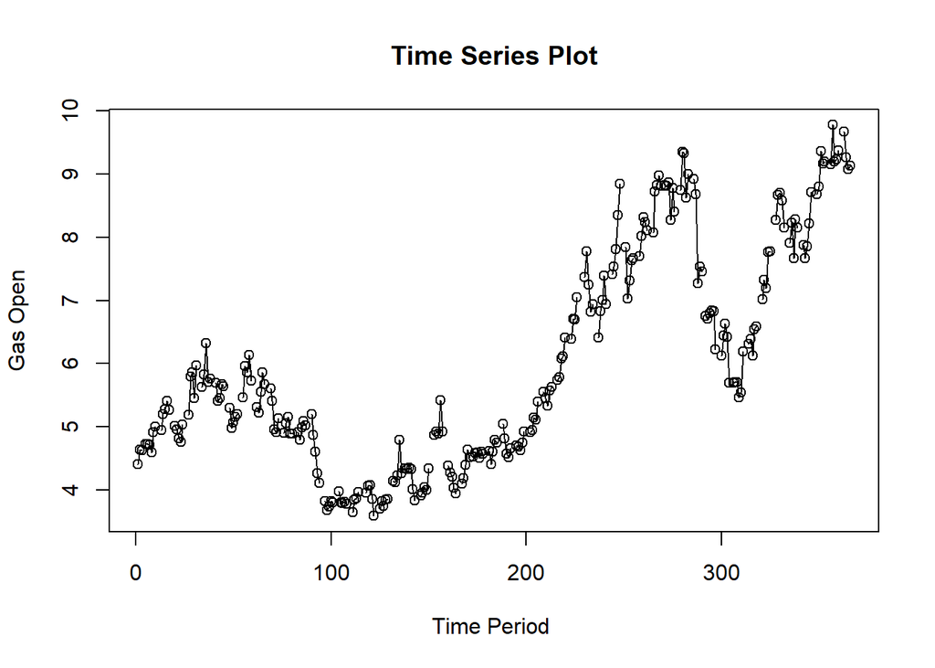

```r
ts.plot(gasopen.ts, xlab="Time Period ", ylab="Gas Open",
        main = "Time Series Plot")
points(gasopen.ts)
```

# Imputasi Data Hilang

```r
#install.packages("imputeTS")
library(imputeTS)
```

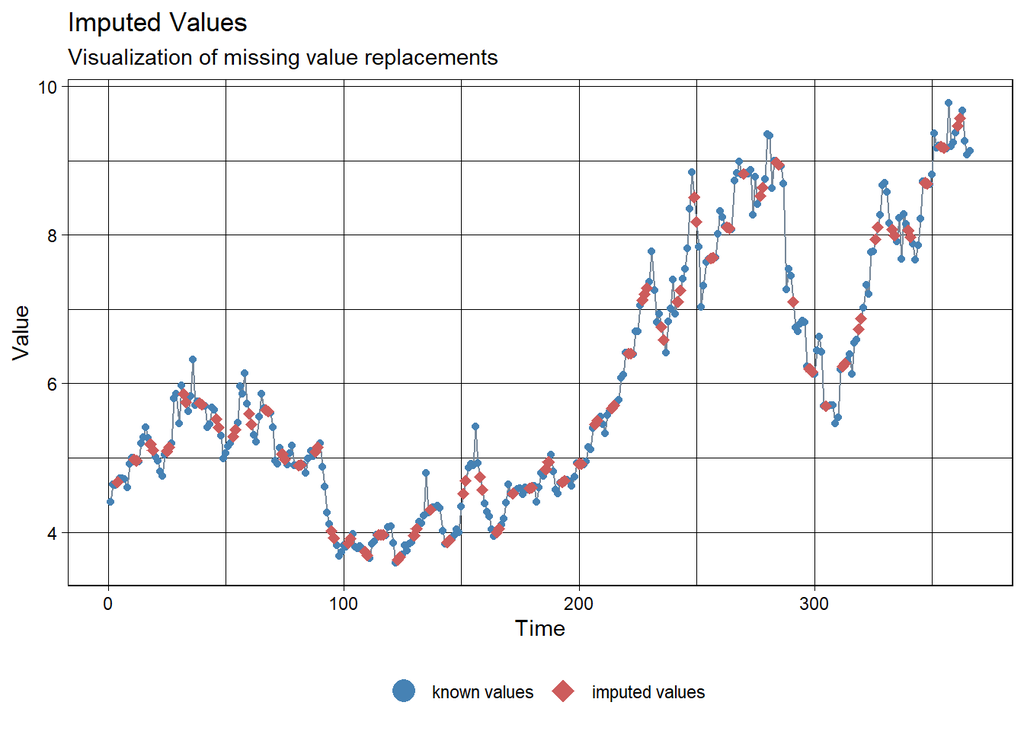

```r
gas.open<- na_interpolation(gas_clean$Open)
ggplot_na_imputations(gas_clean$Open,gas.open)
```

# Data Penuh

## Data Saham Gas Open Setelah Imputasi

```r
View(gas.open)
str(gas.open)
```

```
##  num [1:366] 4.4 4.64 4.63 4.68 4.73 ...
```

```r
summary(gas.open)
```

```
##    Min. 1st Qu.  Median    Mean 3rd Qu.    Max.
##   3.589   4.661   5.484   5.969   7.306   9.780
```

```r
gasopen.ts <- ts(gas.open)
```

## Plot Time Series Data Saham Gas Open Setelah Imputasi

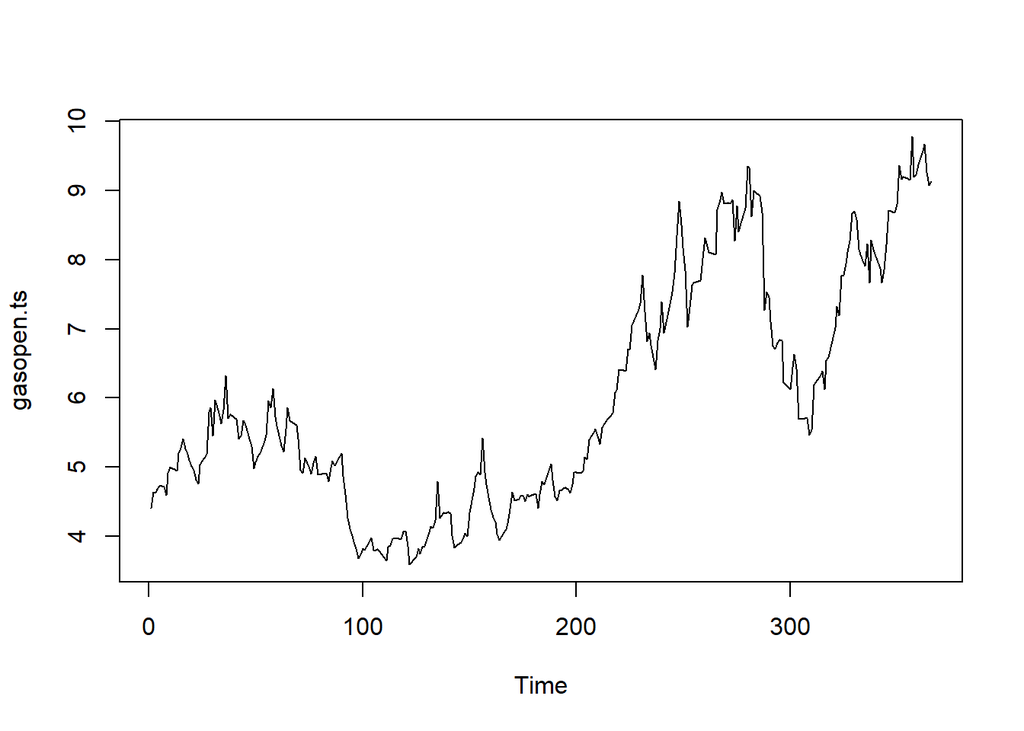

```r
plot_gasopen <- plot(gasopen.ts)
```

Tampak bahwa data memiliki kecenderungan data trend, tidak konstan dalam rataan maupun ragam sehingga data termasuk dalam data tidak stasioner

## Plot ACF

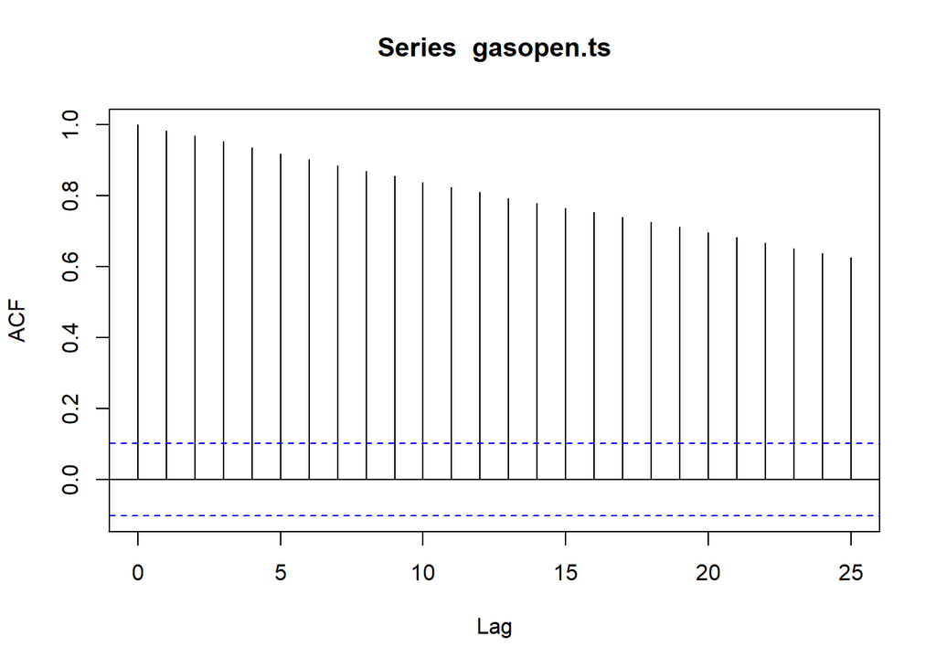

```r
acf(gasopen.ts)
```

Tampak bahwa data *tails off slowly* yang menandakan data tidak stasioner

## Uji ADF

```r
tseries::adf.test(gasopen.ts)
```

```
##
##  Augmented Dickey-Fuller Test
##
## data:  gasopen.ts
## Dickey-Fuller = -1.9321, Lag order = 7, p-value = 0.6056
## alternative hypothesis: stationary
```

$H_0$ : Data tidak stasioner dalam rataan

$H_1$ : Data stasioner dalam rataan

Berdasarkan uji ADF tersebut, didapat *p-value* sebesar 0.6056 yang lebih besar dari taraf nyata 5% sehingga terima $H_0$ dan menandakan bahwa data tidak stasioner dalam rataan. Hal ini sesuai dengan hasil eksplorasi menggunakan plot time series dan plot ACF.

## Plot Box-Cox

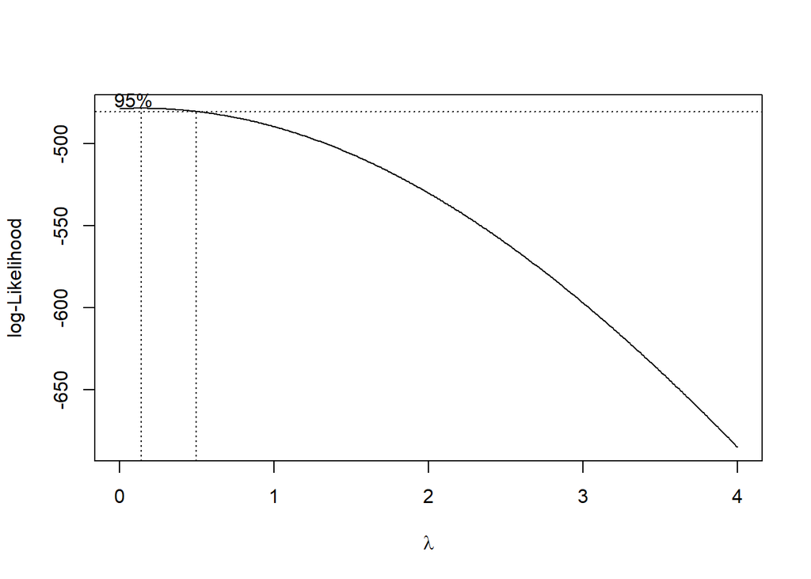

```r
index <- seq(1:366)
bc = boxcox(gasopen.ts~index, lambda = seq(0,4,by=0.01))
```

```r
#Nilai Rounded Lambda
lambda <- bc$x[which.max(bc$y)]
lambda
```

```
## [1] 0.14
```

```r
#SK
bc$x[bc$y > max(bc$y) - 1/2 * qchisq(.95,1)]
```

```
##  [1] 0.00 0.01 0.02 0.03 0.04 0.05 0.06 0.07 0.08 0.09 0.10 0.11 0.12 0.13 0.14
## [16] 0.15 0.16 0.17 0.18 0.19 0.20 0.21 0.22 0.23 0.24 0.25 0.26 0.27 0.28 0.29
## [31] 0.30 0.31 0.32 0.33 0.34 0.35 0.36 0.37 0.38 0.39 0.40 0.41 0.42 0.43 0.44
## [46] 0.45 0.46 0.47 0.48 0.49
```

Gambar di atas menunjukkan nilai *rounded value* ($\lambda$) optimum sebesar **0.14** dan pada selang kepercayaan 95% nilai memiliki batas bawah **0.00** dan batas atas **0.49**. Selang tersebut tidak memuat nilai satu sehingga dapat dikatakan bahwa data penuh gasopen tidak stasioner dalam ragam.

Berdasarkan plot time series, plot ACF, plot ADF, dan Uji Box Cox dapat disimpulkan bahwa data penuh saham bukaan (gasopen) tidak stasioner baik secara rataan maupun secara ragam.

# Partisi

## Bagian 1

Berdasarkan data penuh tampak ada data bagian awal yang cukup stasioner rataan lalu setelahnya mengalami trend naik terus Oleh karena itu, saya mencoba untuk partisi data 1 pada data yang tampak cukup stasioner di awal

### Data

```r
dt_gasopen1 <- gas.open[1:30] |> ts()
mean(dt_gasopen1)
```

```
## [1] 5.0158
```

```r
var(dt_gasopen1)
```

```
## [1] 0.1130333
```

#### Plot Time Series

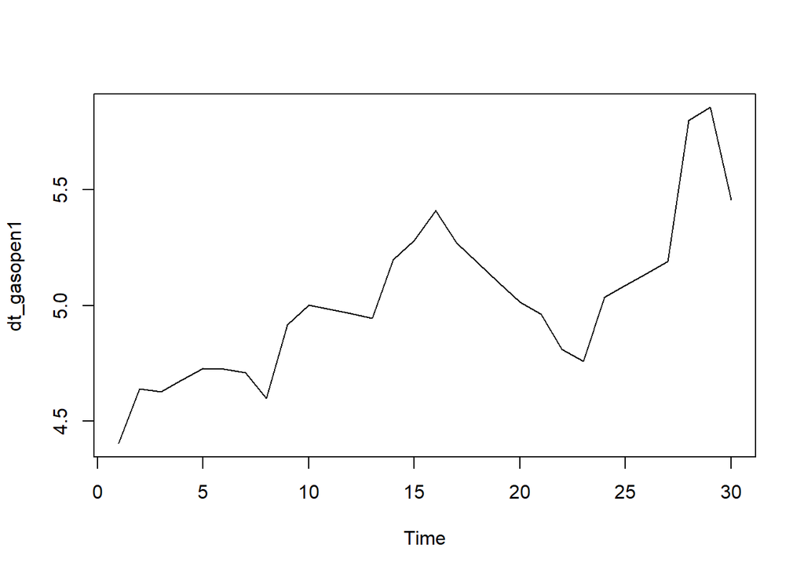

```r
plot(dt_gasopen1)
```

Data tampak seperti memiliki trend sehingga diduga tidak stasioner baik rataan maupun ragam, namun perlu diuji lebih lanjut

#### Plot ACF

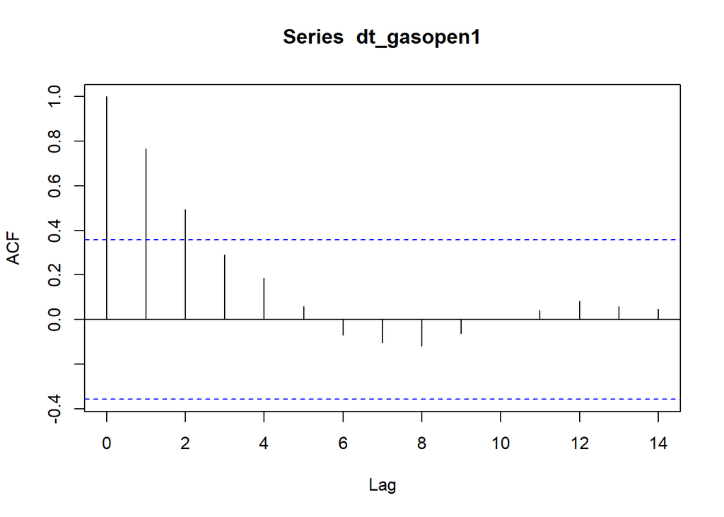

```r
acf(dt_gasopen1)
```

Tampak pada plot ACF, data partisi 1 cenderung *tails off* dan membentuk gelombang sinus sehingga data dapat dikatakan stasioner secara rataan

#### Uji ADF

```r
tseries::adf.test(dt_gasopen1)
```

```
##
##  Augmented Dickey-Fuller Test
##
## data:  dt_gasopen1
## Dickey-Fuller = -1.9897, Lag order = 3, p-value = 0.5766
## alternative hypothesis: stationary
```

$H_0$ : Data tidak stasioner dalam rataan

$H_1$ : Data stasioner dalam rataan

Berdasarkan uji ADF tersebut, didapat *p-value* sebesar 0.5766 yang lebih besar dari taraf nyata 5% sehingga terima $H_0$ dan menandakan bahwa data tidak stasioner dalam rataan. Hal ini tidak sesuai dengan hasil eksplorasi menggunakan plot ACF yang *tails off* dan membentuk gelombang sinus, pertanda data stasioner rataan

Saya juga sudah mencoba untuk menaikkan k yang mana k awal = 3 hingga batas atas k=13 karena pada k=14 muncul p-value NA, hasil semua uji ADF tetap terima H0, data tidak stasioner dalam rataan, padahal menurut plot ACF, data partisi 1 stasioner dalam rataan.

#### Plot Box Cox

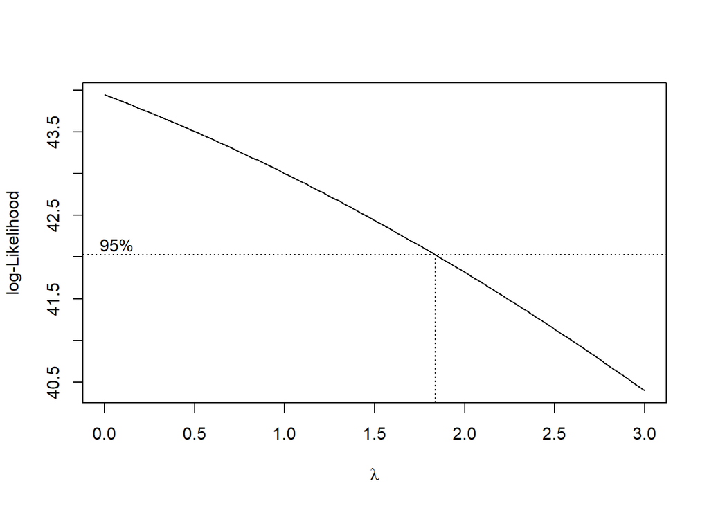

```r
index <- seq(1:30)
bc = boxcox(dt_gasopen1~index, lambda = seq(0,3,by=1))
```

```r
#Nilai Rounded Lambda
lambda <- bc$x[which.max(bc$y)]
lambda
```

```
## [1] 0
```

```r
#SK
bc$x[bc$y > max(bc$y) - 1/2 * qchisq(.95,1)]
```

```
##  [1] 0.00000000 0.03030303 0.06060606 0.09090909 0.12121212 0.15151515
##  [7] 0.18181818 0.21212121 0.24242424 0.27272727 0.30303030 0.33333333
## [13] 0.36363636 0.39393939 0.42424242 0.45454545 0.48484848 0.51515152
## [19] 0.54545455 0.57575758 0.60606061 0.63636364 0.66666667 0.69696970
## [25] 0.72727273 0.75757576 0.78787879 0.81818182 0.84848485 0.87878788
## [31] 0.90909091 0.93939394 0.96969697 1.00000000 1.03030303 1.06060606
## [37] 1.09090909 1.12121212 1.15151515 1.18181818 1.21212121 1.24242424
## [43] 1.27272727 1.30303030 1.33333333 1.36363636 1.39393939 1.42424242
## [49] 1.45454545 1.48484848 1.51515152 1.54545455 1.57575758 1.60606061
## [55] 1.63636364 1.66666667 1.69696970 1.72727273 1.75757576 1.78787879
## [61] 1.81818182
```

Gambar di atas menunjukkan nilai *rounded value* ($\lambda$) optimum sebesar **0.00** dan pada selang kepercayaan 95% nilai memiliki batas bawah **0.00** dan batas atas **1.8181**. Selang tersebut memuat nilai satu sehingga dapat dikatakan bahwa data partisi 1 stasioner dalam ragam.

## Bagian 2

Berdasarkan data penuh tampak ada data bagian awal yang cukup stasioner rataan lalu setelahnya mengalami trend naik terus Oleh karena itu, saya mencoba untuk partisi data 2 pada data yang mengalami trend naik terus menerus

### Data

```r
dt_gasopen2 <- gas.open[100:200] |> ts()
mean(dt_gasopen2)
```

```
## [1] 4.277054
```

```r
var(dt_gasopen2)
```

```
## [1] 0.1705557
```

#### Plot Time Series

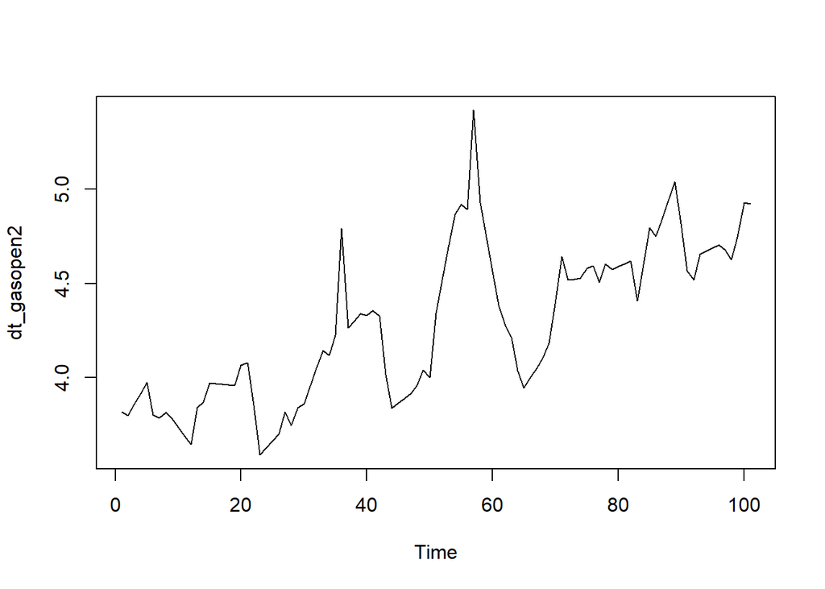

```r
plot(dt_gasopen2)
```

Data tampak seperti memiliki trend sehingga diduga tidak stasioner baik rataan maupun ragam, namun perlu diuji lebih lanjut

#### Plot ACF

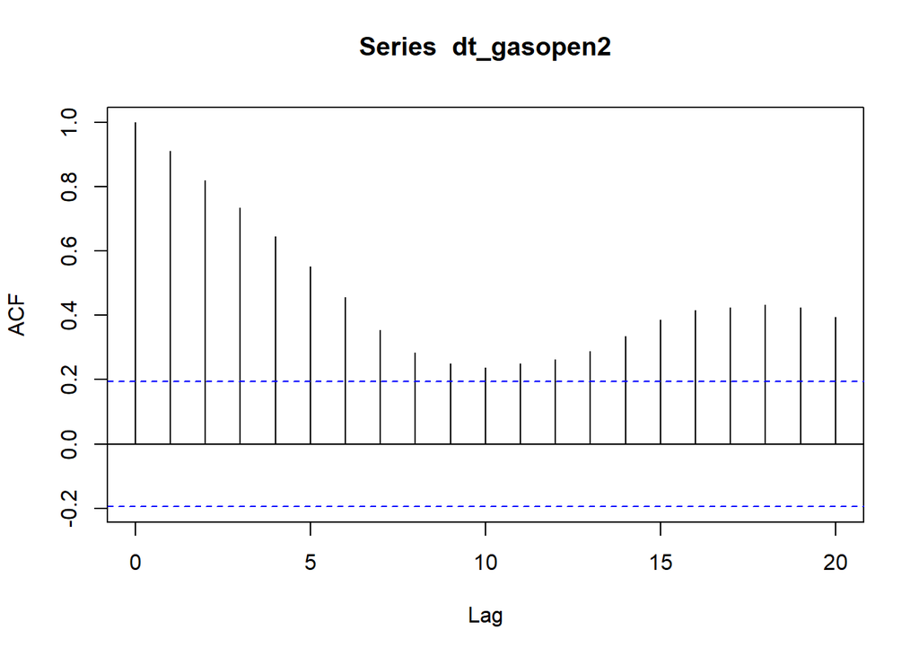

```r
acf(dt_gasopen2)
```

Tampak pada plot ACF, data partisi 2 cenderung *tails off slowly* sehingga data dapat dikatakan tidak stasioner secara rataan

#### Uji ADF

```r
tseries::adf.test(dt_gasopen2,k=10)
```

```
##
##  Augmented Dickey-Fuller Test
##
## data:  dt_gasopen2
## Dickey-Fuller = -3.4052, Lag order = 10, p-value = 0.05746
## alternative hypothesis: stationary
```

$H_0$ : Data tidak stasioner dalam rataan

$H_1$ : Data stasioner dalam rataan

Berdasarkan uji ADF tersebut, didapat *p-value* sebesar 0.05746 yang lebih besar dari taraf nyata 5% sehingga terima $H_0$ dan menandakan bahwa data tidak stasioner dalam rataan. Hal ini sesuai dengan hasil eksplorasi menggunakan plot ACF yang *tails off slowly*, pertanda data tidak stasioner rataan

#### Plot Box Cox

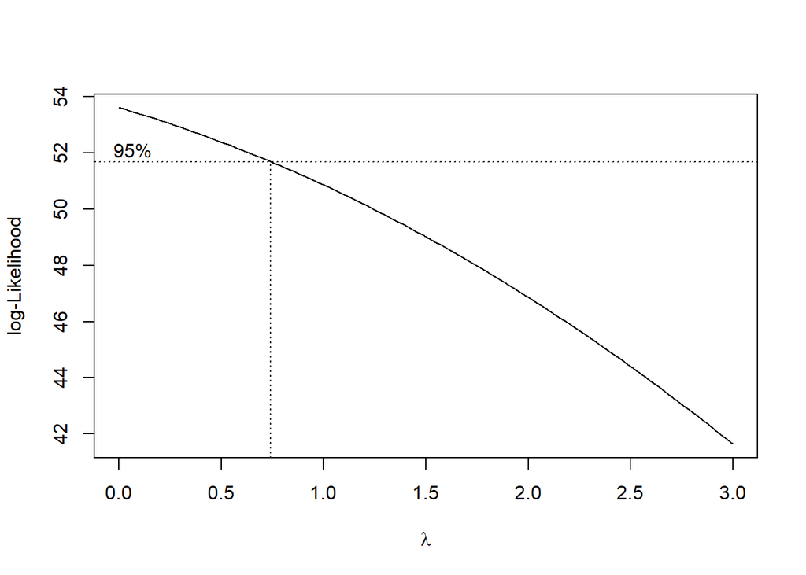

```r
index <- seq(100:200)
bc = boxcox(dt_gasopen2~index, lambda = seq(0,3,by=1))
```

```r
#Nilai Rounded Lambda
lambda <- bc$x[which.max(bc$y)]
lambda
```

```
## [1] 0
```

```r
#SK
bc$x[bc$y > max(bc$y) - 1/2 * qchisq(.95,1)]
```

```
##  [1] 0.00000000 0.03030303 0.06060606 0.09090909 0.12121212 0.15151515
##  [7] 0.18181818 0.21212121 0.24242424 0.27272727 0.30303030 0.33333333
## [13] 0.36363636 0.39393939 0.42424242 0.45454545 0.48484848 0.51515152
## [19] 0.54545455 0.57575758 0.60606061 0.63636364 0.66666667 0.69696970
## [25] 0.72727273
```

Gambar di atas menunjukkan nilai *rounded value* ($\lambda$) optimum sebesar **0.00** dan pada selang kepercayaan 95% nilai memiliki batas bawah **0.00** dan batas atas **0.7272**. Selang tersebut tidak memuat nilai satu sehingga dapat dikatakan bahwa data partisi 2 tidak stasioner dalam ragam.

Berdasarkan plot time series, plot ACF, uji ADF, dan Uji Box Cox dapat disimpulkan bahwa data saham bukaan (gasopen) partisi 2 tidak stasioner baik secara rataan maupun secara ragam.